# Machine Learning Project

January 28, 2016

#### Human Activity Recognition (http://groupware.les.inf.puc-rio.br/har)

In this exercise I am going to predict the manner in which the people we have data for did the exercise they ended up doing. The variable that indicates this exercise is called “classe” in the training set and that is what I will be predicting. The data in this analysis all came from source: http://groupware.les.inf.puc-rio.br/har. who have been very generous in allowing their data to be used for this kind of exercise. I will be using use the other variables (other than “classe”) to predict with. This is my report describing how I built my model, and how Iused cross validation, what I think the expected out of sample error is, and why I made the choices I did. I will also use my prediction model to predict 20 different test cases.

Reproducibility Due to security concerns with the exchange of R code, my code will not be run during the evaluation by you, my classmates. You will be be able to view the compiled HTML version of my analysis which I will publish under Rpubs and provide a link.

required packages: lattice and ggplot2

### Load my libraries

```r
library(caret)
```

```r
library(rpart)
library(rpart.plot)
library(RColorBrewer)
library(randomForest)
```

### Load the Data

Setting a seed number for Reproducibility Load the Data for analysis

```r
set.seed(54321)

#
# Pull the Training data into the trainData variable in memory
#
trainData <- read.table("https://d396qusza40orc.cloudfront.net/predmachlearn/pml-training.csv",
                        header=TRUE, sep=",", na.strings=c("NA","#DIV/0!",""), dec=".", strip.white=TRUE)

dim(trainData)
```

```
## [1] 19622   160
```

```r
#
# Pull the Test data into the testData variable in memory
#
testData <- read.table("https://d396qusza40orc.cloudfront.net/predmachlearn/pml-testing.csv",
                       header=TRUE, sep=",", na.strings=c("NA","#DIV/0!",""), dec=".", strip.white=TRUE)
dim(testData)
```

```
## [1]  20 160
```

### Cleaning the Data

Now I want to cleanup the near zero variance Get rid of the near zero variances as they will cause poor results in my final prediction model.

```r
trainingNZV <- nearZeroVar(trainData, saveMetrics=TRUE)
trainingCleanup <- trainData[!trainingNZV$nzv]
dim(trainingCleanup)
```

```
## [1] 19622   124
```

Get rid of the first column. X is a sequential number for each row so not really going to help with predicting anything.

```r
trainingCleanup <- trainingCleanup[c(-1)]
```

Now, i want to get rid of variables with too many Null values. For Variables that have more than a 30% threshold of Null values; I’m going to leave them out:

```r
trainingFinal <- trainingCleanup
for(a in 1:length(trainingCleanup)) {
  if(sum(is.na(trainingCleanup[,a]))/nrow(trainingCleanup) >= .3 ) {
    for(b in 1:length(trainingFinal)) {
      if(length(grep(names(trainingCleanup[a]), names(trainingFinal)[b]))==1) {
        trainingFinal <- trainingFinal[,-b]
      }
    }
  }
}

dim(trainingFinal)
```

```
## [1] 19622    58
```

### Partition the data for model fitting

Now, I want to partition the trainData into a training set and a testing set for analysis and formula fitting.

```r
myTrainingPartition <- createDataPartition(y=trainingFinal$classe, p=0.60, list=FALSE)
myTraining <- trainingFinal[myTrainingPartition, ]
myTesting <- trainingFinal[-myTrainingPartition, ]

dim(myTraining)
```

```
## [1] 11776    58
```

```r
dim(myTesting)
```

```
## [1] 7846   58
```

I will now take the columns from myTraining that I am going to use in the model and only keep those columns from the testData that match.

```r
clean <- colnames(myTraining[, -58])
testData <- testData[clean]
```

Making sure to sync with the same class between myTraining and the testData

```r
testData <- rbind(myTraining[2, -58] , testData)
testData <- testData[-1,]
```

### Finding the best fit prediction model

Trying the ML algorithms for prediction: Decision Tree

```r
fit.dt <- rpart(classe ~ ., data=myTraining, method="class")
```

```r
predictions.dt <- predict(fit.dt, myTesting, type = "class")
```

Here is the confusionMatrix to see the results of Decision Tree

```r
confusionMatrix(predictions.dt, myTesting$classe)
```

```
## Confusion Matrix and Statistics
##
##           Reference
## Prediction    A    B    C    D    E
##          A 2154   60    7    3    0
##          B   75 1378  110    7    0
##          C    3   73 1226  118   57
##          D    0    7   15  970   77
##          E    0    0   10  188 1308
##
## Overall Statistics
##
##                Accuracy : 0.8968
##                  95% CI : (0.8898, 0.9034)
##     No Information Rate : 0.2845
##     P-Value [Acc > NIR] : < 2.2e-16
##
##                   Kappa : 0.8694
##  Mcnemar's Test P-Value : NA
##
## Statistics by Class:
##
##                      Class: A Class: B Class: C Class: D Class: E
## Sensitivity            0.9651   0.9078   0.8962   0.7543   0.9071
## Specificity            0.9875   0.9697   0.9613   0.9849   0.9691
## Pos Pred Value         0.9685   0.8777   0.8301   0.9074   0.8685
## Neg Pred Value         0.9861   0.9777   0.9777   0.9534   0.9789
## Prevalence             0.2845   0.1935   0.1744   0.1639   0.1838
## Detection Rate         0.2745   0.1756   0.1563   0.1236   0.1667
## Detection Prevalence   0.2835   0.2001   0.1882   0.1362   0.1919
## Balanced Accuracy      0.9763   0.9387   0.9287   0.8696   0.9381
```

Using ML algorithms for prediction: Random Forests

```r
fit.rf <- randomForest(classe ~. , data=myTraining)
```

```r
predictions.rf <- predict(fit.rf, myTesting, type = "class")
```

Here is the confusionMatrix to see the results of Random Forest

```r
confusionMatrix(predictions.rf, myTesting$classe)
```

```
## Confusion Matrix and Statistics
##
##           Reference
## Prediction    A    B    C    D    E
##          A 2229    0    0    0    0
##          B    3 1518    1    0    0
##          C    0    0 1366    4    0
##          D    0    0    1 1282    1
##          E    0    0    0    0 1441
##
## Overall Statistics
##
##                Accuracy : 0.9987
##                  95% CI : (0.9977, 0.9994)
##     No Information Rate : 0.2845
##     P-Value [Acc > NIR] : < 2.2e-16
##
##                   Kappa : 0.9984
##  Mcnemar's Test P-Value : NA
##
## Statistics by Class:
##
##                      Class: A Class: B Class: C Class: D Class: E
## Sensitivity            0.9987   1.0000   0.9985   0.9969   0.9993
## Specificity            1.0000   0.9994   0.9994   0.9997   1.0000
## Pos Pred Value         1.0000   0.9974   0.9971   0.9984   1.0000
## Neg Pred Value         0.9995   1.0000   0.9997   0.9994   0.9998
## Prevalence             0.2845   0.1935   0.1744   0.1639   0.1838
## Detection Rate         0.2841   0.1935   0.1741   0.1634   0.1837
## Detection Prevalence   0.2841   0.1940   0.1746   0.1637   0.1837
## Balanced Accuracy      0.9993   0.9997   0.9990   0.9983   0.9997
```

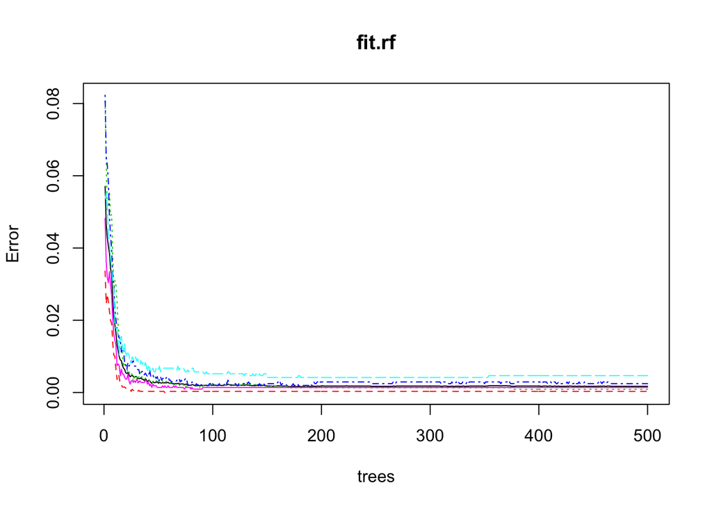

```r
plot(fit.rf)
```

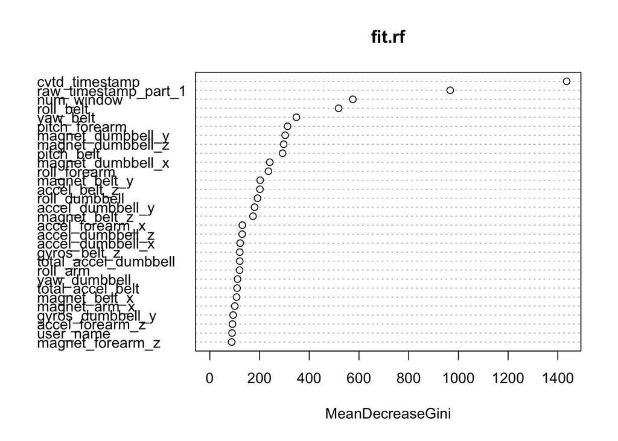

```r
varImpPlot(fit.rf)
```

### Choice of best fit is:

Random Forests is a better fit for predicting in this case Here is the prediction Random Forests gave an Accuracy in the myTesting dataset of 99.87% which was more accurate that from the Decision Tree.

The expected out-of-sample error is 100-99.87 = 0.13%.

Since the sample error is low, this suggests to me that my prediction model is accurate and therefore, a good fit.

### Predictions of test data

```r
predictions.rf.test <- predict(fit.rf, testData, type = "class")
predictions.rf.test
```

```
## 22  3  4  5  6  7  8  9 10 11 12 13 14 15 16 17 18 19 20 21
##  B  A  B  A  A  E  D  B  A  A  B  C  B  A  E  E  A  B  B  B
## Levels: A B C D E
```